# 12-mapping

Ryan Thornburg

2022-11-12

```r
knitr::opts_chunk$set(echo = TRUE)
knitr::opts_knit$set(root.dir = '~/Documents/MEJO570F22')
```

### Packages we will be using in this lesson:

- tidyverse
- ggplot
- tidycensus
- sf

Much of this lesson was adapted from these two sources, which can be used for support and reference as you work on the assignment: * https://learn.r-journalism.com/en/mapping/ * Chapters 17, 20 and 21 of https://mattwaite.github.io/datajournalism/

```r
pacman::p_load(sf, tidyverse)
#Do you want to install from sources the package which needs compilation? (Yes/no/cancel) no
#If this gives us error messages, let's install and load sf manually.
```

If it asks you if you want to install the “source” package say “no”. Otherwise you will get this error message and you will need to uninstall and reinstall tidycensus.

(When installing tidycensus, it installs sf and I get “configure: error: gdal-config not found or not executable.”)

## Part 1: Mapping Hospital Beds in North Carolina Counties

The U.S. Department of Homeland Security collects “Homeland Infrastructure Foundation-Level Data” in order “to support community preparedness, resiliency, research, and more.”

One of the pieces of data it collects and shares with the public is information about all the hospitals in the United States, including the number of beds and their location.

Source: https://hifld-geoplatform.opendata.arcgis.com/ Source: https://hifld-geoplatform.opendata.arcgis.com/datasets/hospitals/explore?location=21.228667%2C-115.674385%2C3.62 Data Dictionary: https://hifld-geoplatform.opendata.arcgis.com/datasets/geoplatform::hospitals/about

Before you download the Shapefile and get into that, go ahead and download a version that’s in a file format with which you’re already familiar. In this case, we see a CSV file that should open up easily in Excel or Google Sheets.

In addition to the CSV and Shapefile formats, you will see file such as KML (keyhole markup language, used for Google Maps and other stuff() and GeoJSON, which is often used for building interactive web apps.

Note that the Shapefile data we download gives us a .zip file format that we will have to decompress. When we decompress `Hospitals.zip` we will get a new directory/folder on our computer called `Hospitals`. It’s inside this directory/folder that we will find our `Hospitals.shp` file.

Whatever you do, don’t separate this `Hospitals.shp` from its family. It needs all the other little files – Hospitals.xml, Hospitals.dbf, Hispitals.shx, Hospitals.cpg, and Hospitals.prj – with it in the same directory in order for it to behave properly.

```r
hospitals <- sf::st_read("Hospitals/Hospitals.shp")
```

#1. From the `hospitals` sf object, create an sf object that contains just the hospitals in North Carolina.

```r
nc <- hospitals %>% filter(STATE == "NC")
```

#2. Use geom_sf from ggplot to make a map of the hospitals in North Carolina.

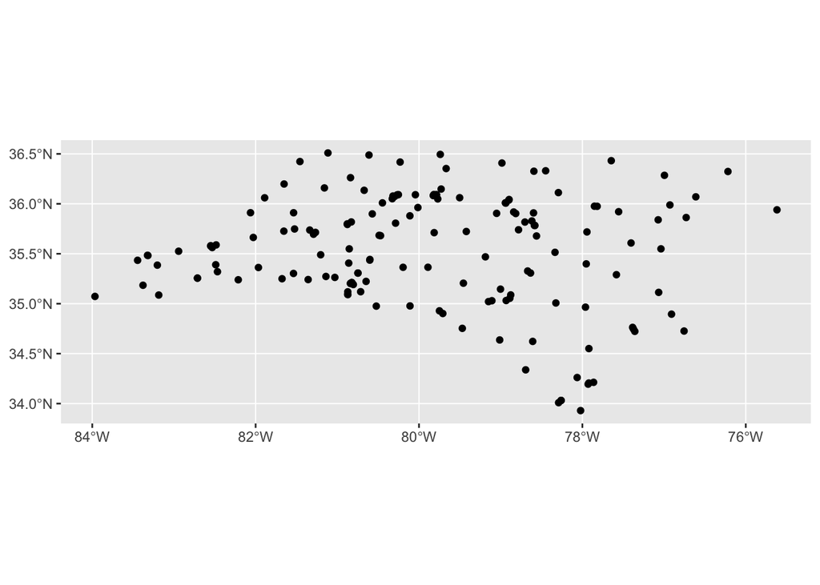

```r
ggplot() + geom_sf(data=nc)
```

#3. Use your Census API key and tidycensus to download the shapes of North Carolina counties along with the Tidycensus package

References: * http://api.census.gov/data/key_signup.html * https://walker-data.com/tidycensus/index.html * https://walker-data.com/tidycensus/reference/census_api_key.html * https://censusreporter.org/ * https://github.com/walkerke/tigris * https://walker-data.com/census-r/index.html

```r
#I've had problems using pacman::p_load() with tidycensus
#install.packages("tidycensus")
library(tidycensus)
#census_api_key("", install= TRUE)

#Pro tip: Turn off VPN before hitting api.census.gov


ncpop <- get_acs(geography = "county",
              variables = c(population = "B01003_001"),
              state = "NC",
              year = 2020,
              geometry=T)
```

#4. Use geom_sf() to make a map of the counties in North Carolina

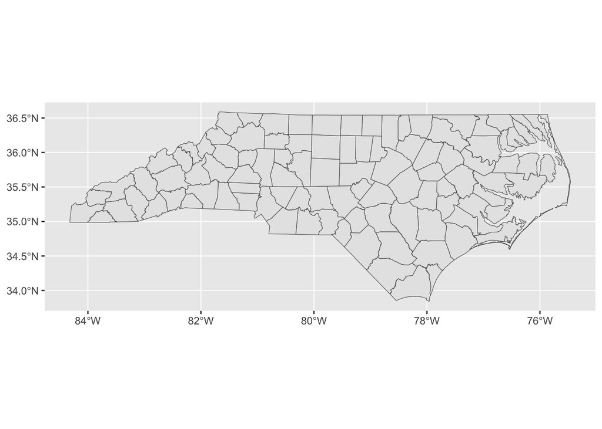

```r
ggplot() + geom_sf(data=ncpop)
```

# 5. Make a map of hospitals and counties.

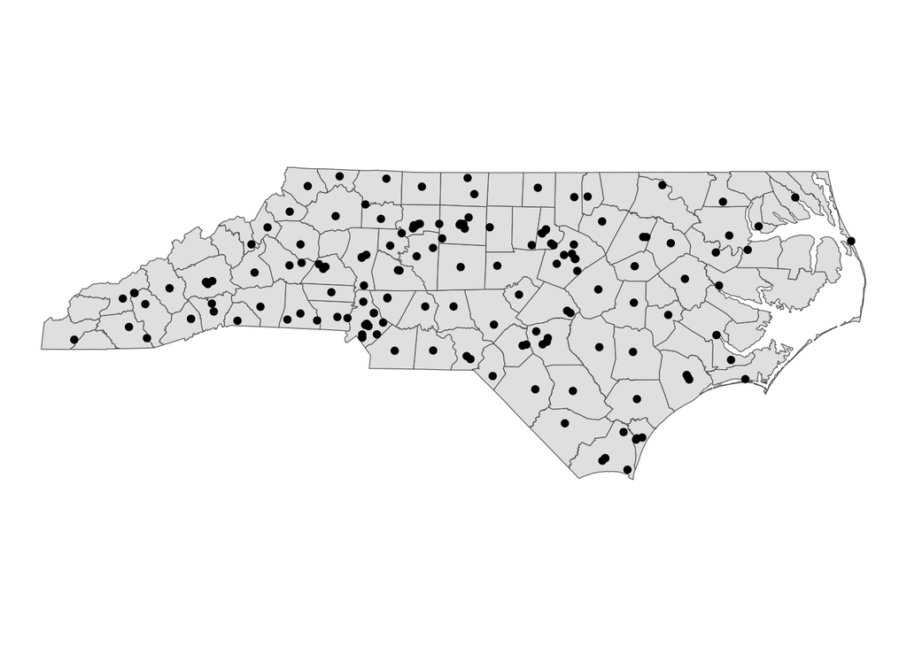

```r
ggplot() + geom_sf(data=ncpop) + geom_sf(data=nc) + theme_void()
```

The map we just made makes it easy to see that some counties have more hospitals than others. In fact, we see that some counties have no hospitals at all. But we know that some hospitals are bigger than others. And we also know that some counties have more people than others. Maybe every county has the same hospital capacity relative to its population. We might operationalize “hopital capacity” as total hospital beds in a county divided by total population. Let’s map that…

# 6. Join the hospital location data to the Census data.

```r
# First, let's use the DHS data to add up the the number of beds in each county.


ncbeds <- nc %>%
  filter(BEDS > 0) %>%
  group_by(COUNTY) %>%
  summarize(county_beds = sum(BEDS)) %>%
#I suspect there's a better way to do this, but I found that select() doesn't work with sf objects. So I temporarily convert it to a "tibble," which is a "lazy and surly" type of data frame that you can read more about here: https://tibble.tidyverse.org/
  as_tibble() %>%
  select(COUNTY, county_beds)



#Now we notice that there is no column in ncpop that contains EXACTLY the same values that are contained in the COUNTY column in ncbeds. Human minds are flexible and can see that the NAME column in ncpop is the name of the county, but inflexible computers can't figure that out. So if you asked a computer to join these two dataframes by matching the ncpop$COUNTY to ncbeds$name, the computer would be all, like, "Nope, no matches." And you'd be all, like, "Stupid computer! I can see the matches right there!"

#So here we have to help out by first making sure that the NAME column doesn't have any leading or trailing invisible white spaces, then we have to chop off the " County, North Carolina" characters, and then finally convert the proper casing to all upper case (again, because computers are REALLY inflexible and dumb). Finally, to do just one nice thing for our own human minds, we'll change the name of the NAME column to a more descriptive -- and easier to join -- COUNTY.

ncpop <- ncpop %>%
  mutate(COUNTY = str_trim(NAME)) %>%
  mutate(COUNTY = str_sub(COUNTY,1,str_length(COUNTY)-23)
         ) %>%
  mutate(COUNTY = str_to_upper(COUNTY))


#Then we just join. And don't even have to explicitly tell R which columns to join because we've made it perfectly clear to our hard-working but somewhat dense computer helper.

ncall <- left_join(ncpop, ncbeds,
                         # by=c("COUNTY"="COUNTY")
                   )
ncall<- ncall %>%
  mutate(pop_per_bed = estimate / county_beds)
```

# 7. Map beds per person.

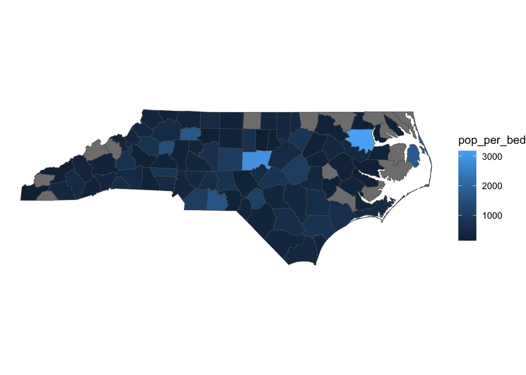

```r
ggplot() +
  geom_sf(data=ncall,
          aes(fill=pop_per_bed)) +
  theme_void()
```

Those gray counties indicate counties that don’t have any hospitals. That might be exactly the story you want to tell. But you also might want to say, “Well, I want to show how many people in each of those counties don’t have a bed. I can’t divide by zero. Taking the entire population might be less precise but more enlightening. Let’s do that. We can use a new function called `coalesce()` from the tidyverse to”mush together” the values in the estimate column with the NA values in the pop_per_bed column. A better description of coalsce() is at https://dplyr.tidyverse.org/reference/coalesce.html

```r
ncall<- ncall %>%
  #mutate(pop_per_bed = estimate / county_beds) %>%
  relocate(pop_per_bed, .after = county_beds) %>%
  mutate(pop_per_bed = coalesce(pop_per_bed, estimate))
```

# 8. Add the following information to our map:

*A title that says “16 Counties Have People, But No Hospital”* A caption that says “Source: US Census, Department of Homeland Security” *A title for the legend that says “People Per Bed”* Make the counties that have more people per bed darker than the counties that have fewer people per bed.

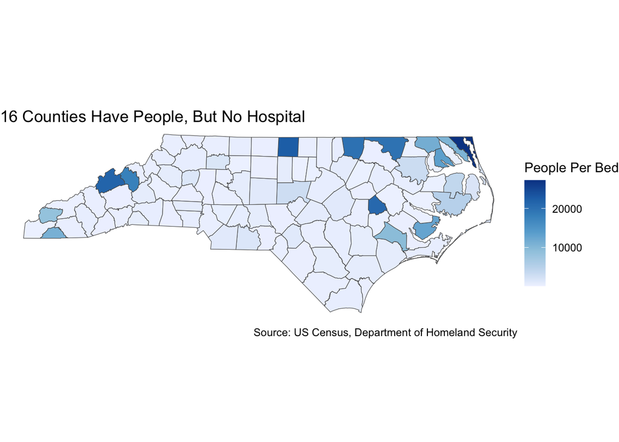

```r
ggplot() +
  geom_sf(data=ncall, aes(fill=pop_per_bed)) +
  scale_fill_distiller(direction=1, name="People Per Bed") +
  labs(title="16 Counties Have People, But No Hospital", caption="Source: US Census, Department of Homeland Security") +
  theme_void()
```

### Time for a little break

Tidycensus will give you acess to a lot of Census data, but not everything. If you want access to the ENTIRE Census API via R, the best tool is the “censusapi” package created by journalist Hannah Recht: https://www.hrecht.com/censusapi/articles/getting-started.html

When you install tidycensus, you’re also installing the “tigris” package. The tigris package has some useful tools that you can use independently of tidycensus. For example, you can use tigris just to download shapefiles without any data assocaited with them. You can also use a function called `shift_geometry()` when you’re making a national map and want Alaska and Hawaii to appear in a layout-friendly location somewhere off the Pacific coast of Mexico.

The example below uses that tigris function and also a package called viridis, which gives you some nice color palletes that people who know say are useful for choropleth maps: https://www.thinkingondata.com/something-about-viridis-library/

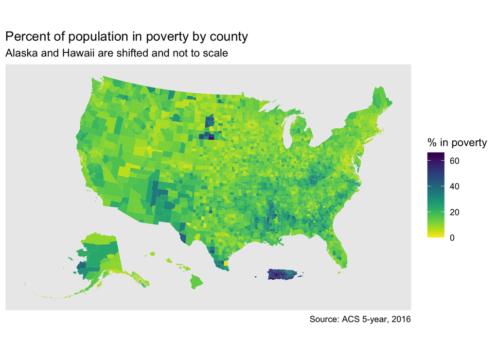

```r
#install.packages("viridis")

county_pov <- get_acs(geography = "county",
                      variables = "B17001_002",
                      summary_var = "B17001_001",
                      geometry = TRUE) %>%
  tigris::shift_geometry() %>%
  mutate(pctpov = 100 * (estimate/summary_est))
ggplot(county_pov) +
  geom_sf(aes(fill = pctpov), color=NA) +
  coord_sf(datum=NA) +
  labs(title = "Percent of population in poverty by county",
       subtitle = "Alaska and Hawaii are shifted and not to scale",
       caption = "Source: ACS 5-year, 2016",
       fill = "% in poverty") +
  viridis::scale_fill_viridis(direction=-1)
```

But of course in the real world county borders don’t confine the hospital beds that peolpe use. We can get R to show us the density of our hospital points by doing a “kernel density estimate” for us. Our new function here is ggplot geom called `stat_density2d()`. More at https://ggplot2.tidyverse.org/reference/geom_density_2d.html

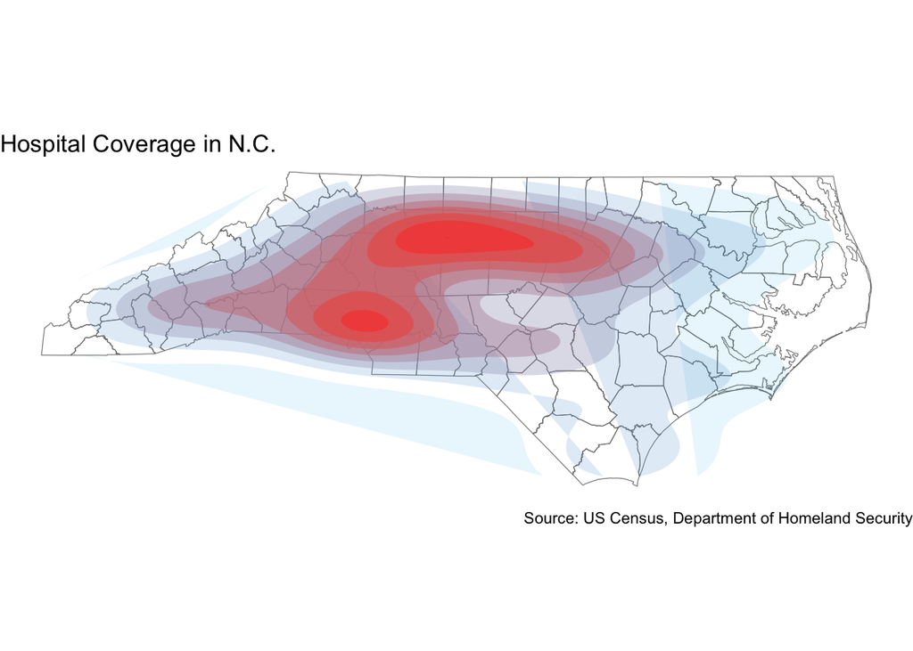

```r
ggplot() +
  geom_sf(data=ncpop,
          color = "#777777",
          fill=NA,
          size=0.2) +
  stat_density2d(data=nc,
                 show.legend=F,
                 aes(x=LONGITUDE,
                     y=LATITUDE,
                     fill=after_stat(level),
                     alpha=after_stat(level)
                     ),
                 geom="polygon",
                 size=4,
                 bins=10) +
  scale_fill_gradient(low="deepskyblue2",
                      high="firebrick1",
                      name="Distribution") +
  labs(x=NULL, y=NULL,
                  title="Hospital Coverage in N.C.",
                  subtitle=NULL,
                  caption="Source: US Census, Department of Homeland Security") +
  theme_void() +
  theme(panel.grid.major = element_line(colour = 'transparent'))
```

## Part 2: Finding Overlapping Geometries with Hospitals and Congressional Districts

We’ve plotted points (hospitals). We’ve plotted polygons (counties). We’ve plotted the points on top of the polygons. And by using a common value in our points and polygon sf objects, we’ve joined them together like we would any old other dataframe and then mapped the number of beds in each county.

But what if we wanted to count the number of hospital points inside some OTHER kind of polygon – and one for which we don’t have a column to join on. For example, we might wonder which voting precinct each hospital is in. I’m not sure why we’d want to know that, but if we did, we couldn’t do it… UNLESS we could ask R to tell us which hospital’s latitude and longitude points fell within the boundaries of each polygon.

This is called finding the points-in-polygon, and it’s just one of many different ways we can look for the overlapping relationship between points, lines and polygons on a map.

Finding which hospitals are inside each congressional district is something that might be useful. Maybe because we’re looking at federal funding levels for healthcare or maybe because we’re looking at whether some hospitals get some kind of regulatory relief in a loophole created by a certain member of Congress.

We can use tidycensus to get a map of the (pre-2022) congressional districts in R… (https://walker-data.com/tidycensus/articles/basic-usage.html#geography-in-tidycensus )

# 9. Use tidycensus to get the shapes and populations of North Carolina’s 13 congressional districts as they existed before the 2020 Census. Go ahead and map them to make sure they look OK.

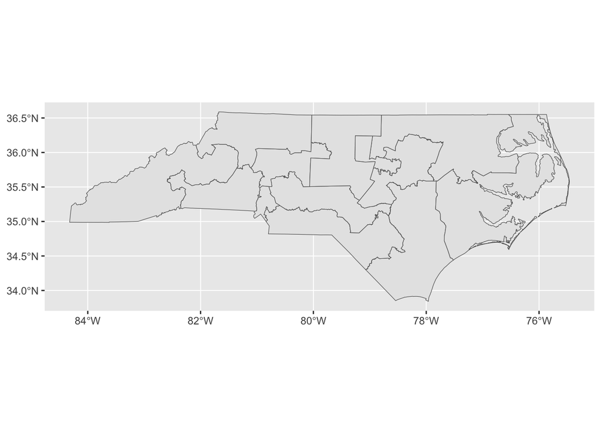

```r
cds<- get_acs(state = "NC",
              geography = "congressional district",
                      variables = "B17001_002",
                      summary_var = "B17001_001",
                      year = 2020,
                      geometry = TRUE)
ggplot() + geom_sf(data=cds)
```

So far we’ve been able to ignore all that “projection” stuff we were talking about at the start of the lesson. But when we want to ask about the intersection of points, lines and polygons we need to be darn certain that the layers we want to compare are in the same projection.

Luckily,the sf package has a way for us to find the CRS for any sf object. The sf package also has a way for us to change the projection of any sf object. And we can use a new-to-us package called *crsuggest* to help us determine the “best” CRS for a given object.

The authory of the tidycensus package has also published a freely available book that provides a good reference for all this CRS stuff: https://walker-data.com/census-r/census-geographic-data-and-applications-in-r.html?q=CRS#coordinate-reference-systems

Let’s check the CRS of the `nc` sf object.

```r
sf::st_crs(nc)
```

```
## Coordinate Reference System:
##   User input: WGS 84
##   wkt:
## GEOGCRS["WGS 84",
##     DATUM["World Geodetic System 1984",
##         ELLIPSOID["WGS 84",6378137,298.257223563,
##             LENGTHUNIT["metre",1]]],
##     PRIMEM["Greenwich",0,
##         ANGLEUNIT["degree",0.0174532925199433]],
##     CS[ellipsoidal,2],
##         AXIS["latitude",north,
##             ORDER[1],
##             ANGLEUNIT["degree",0.0174532925199433]],
##         AXIS["longitude",east,
##             ORDER[2],
##             ANGLEUNIT["degree",0.0174532925199433]],
##     ID["EPSG",4326]]
```

# 10. Check the CRS of the congressional districts we just downloaded.

```r
sf::st_crs(cds)
```

```
## Coordinate Reference System:
##   User input: NAD83
##   wkt:
## GEOGCRS["NAD83",
##     DATUM["North American Datum 1983",
##         ELLIPSOID["GRS 1980",6378137,298.257222101,
##             LENGTHUNIT["metre",1]]],
##     PRIMEM["Greenwich",0,
##         ANGLEUNIT["degree",0.0174532925199433]],
##     CS[ellipsoidal,2],
##         AXIS["latitude",north,
##             ORDER[1],
##             ANGLEUNIT["degree",0.0174532925199433]],
##         AXIS["longitude",east,
##             ORDER[2],
##             ANGLEUNIT["degree",0.0174532925199433]],
##     ID["EPSG",4269]]
```

Dammit. They’re not the same. Is one “better” than the other in this case? Do we need to change both or just one. Let’s use crsuggest to find out.

Reference: https://walker-data.com/census-r/census-geographic-data-and-applications-in-r.html?q=CRS#using-the-crsuggest-package

```r
pacman::p_load(crsuggest)

suggest_crs(nc)
```

```
## # A tibble: 10 × 6
##    crs_code crs_name                             crs_t…¹ crs_gcs crs_u…² crs_p…³
##    <chr>    <chr>                                <chr>     <dbl> <chr>   <chr>
##  1 6543     NAD83(2011) / North Carolina (ftUS)  projec…    6318 us-ft   +proj=…
##  2 6542     NAD83(2011) / North Carolina         projec…    6318 m       +proj=…
##  3 3632     NAD83(NSRS2007) / North Carolina (f… projec…    4759 us-ft   +proj=…
##  4 3631     NAD83(NSRS2007) / North Carolina     projec…    4759 m       +proj=…
##  5 3404     NAD83(HARN) / North Carolina (ftUS)  projec…    4152 us-ft   +proj=…
##  6 3358     NAD83(HARN) / North Carolina         projec…    4152 m       +proj=…
##  7 32119    NAD83 / North Carolina               projec…    4269 m       +proj=…
##  8 32019    NAD27 / North Carolina               projec…    4267 us-ft   +proj=…
##  9 2264     NAD83 / North Carolina (ftUS)        projec…    4269 us-ft   +proj=…
## 10 6570     NAD83(2011) / South Carolina (ft)    projec…    6318 ft      +proj=…
## # … with abbreviated variable names ¹crs_type, ²crs_units, ³crs_proj4
```

Well it looks like crsuggest is uggesting we use good ol’ NAD83 (a CRS that you’ll see a lot). This is probably because the datapoints in our filtered sf object are all inside North Carolina, so we want to use a projection that distorts that section of our shared sphere the least.

NAD83 is the CRS that the congressional districts are already in. But is it the **best** CRS to use? Let’s check.

#11. What is the uggested CRS for the congressional districts?

```r
suggest_crs(cds)
```

```
## # A tibble: 10 × 6
##    crs_code crs_name                             crs_t…¹ crs_gcs crs_u…² crs_p…³
##    <chr>    <chr>                                <chr>     <dbl> <chr>   <chr>
##  1 6543     NAD83(2011) / North Carolina (ftUS)  projec…    6318 us-ft   +proj=…
##  2 6542     NAD83(2011) / North Carolina         projec…    6318 m       +proj=…
##  3 3632     NAD83(NSRS2007) / North Carolina (f… projec…    4759 us-ft   +proj=…
##  4 3631     NAD83(NSRS2007) / North Carolina     projec…    4759 m       +proj=…
##  5 3404     NAD83(HARN) / North Carolina (ftUS)  projec…    4152 us-ft   +proj=…
##  6 3358     NAD83(HARN) / North Carolina         projec…    4152 m       +proj=…
##  7 32119    NAD83 / North Carolina               projec…    4269 m       +proj=…
##  8 32019    NAD27 / North Carolina               projec…    4267 us-ft   +proj=…
##  9 2264     NAD83 / North Carolina (ftUS)        projec…    4269 us-ft   +proj=…
## 10 6570     NAD83(2011) / South Carolina (ft)    projec…    6318 ft      +proj=…
## # … with abbreviated variable names ¹crs_type, ²crs_units, ³crs_proj4
```

Well now that we know that, we need to go ahead and get the hospital points into the NAD83 CRS. We can do that using `st_transform()` function from the sf package. They key here is the second argument in this function, for which we use the appropriate numerical identifier from the crs_code column we get when we run suggest_crs()

```r
cds <- sf::st_transform(cds, crs = 6543)

sf::st_crs(cds)
```

```
## Coordinate Reference System:
##   User input: EPSG:6543
##   wkt:
## PROJCRS["NAD83(2011) / North Carolina (ftUS)",
##     BASEGEOGCRS["NAD83(2011)",
##         DATUM["NAD83 (National Spatial Reference System 2011)",
##             ELLIPSOID["GRS 1980",6378137,298.257222101,
##                 LENGTHUNIT["metre",1]]],
##         PRIMEM["Greenwich",0,
##             ANGLEUNIT["degree",0.0174532925199433]],
##         ID["EPSG",6318]],
##     CONVERSION["SPCS83 North Carolina zone (US Survey feet)",
##         METHOD["Lambert Conic Conformal (2SP)",
##             ID["EPSG",9802]],
##         PARAMETER["Latitude of false origin",33.75,
##             ANGLEUNIT["degree",0.0174532925199433],
##             ID["EPSG",8821]],
##         PARAMETER["Longitude of false origin",-79,
##             ANGLEUNIT["degree",0.0174532925199433],
##             ID["EPSG",8822]],
##         PARAMETER["Latitude of 1st standard parallel",36.1666666666667,
##             ANGLEUNIT["degree",0.0174532925199433],
##             ID["EPSG",8823]],
##         PARAMETER["Latitude of 2nd standard parallel",34.3333333333333,
##             ANGLEUNIT["degree",0.0174532925199433],
##             ID["EPSG",8824]],
##         PARAMETER["Easting at false origin",2000000,
##             LENGTHUNIT["US survey foot",0.304800609601219],
##             ID["EPSG",8826]],
##         PARAMETER["Northing at false origin",0,
##             LENGTHUNIT["US survey foot",0.304800609601219],
##             ID["EPSG",8827]]],
##     CS[Cartesian,2],
##         AXIS["easting (X)",east,
##             ORDER[1],
##             LENGTHUNIT["US survey foot",0.304800609601219]],
##         AXIS["northing (Y)",north,
##             ORDER[2],
##             LENGTHUNIT["US survey foot",0.304800609601219]],
##     USAGE[
##         SCOPE["Engineering survey, topographic mapping."],
##         AREA["United States (USA) - North Carolina - counties of Alamance; Alexander; Alleghany; Anson; Ashe; Avery; Beaufort; Bertie; Bladen; Brunswick; Buncombe; Burke; Cabarrus; Caldwell; Camden; Carteret; Caswell; Catawba; Chatham; Cherokee; Chowan; Clay; Cleveland; Columbus; Craven; Cumberla…
##         BBOX[33.83,-84.33,36.59,-75.38]],
##     ID["EPSG",6543]]
```

```r
nc <- sf::st_transform(nc, crs = 6543)

sf::st_crs(nc)
```

```
## Coordinate Reference System:
##   User input: EPSG:6543
##   wkt:
## PROJCRS["NAD83(2011) / North Carolina (ftUS)",
##     BASEGEOGCRS["NAD83(2011)",
##         DATUM["NAD83 (National Spatial Reference System 2011)",
##             ELLIPSOID["GRS 1980",6378137,298.257222101,
##                 LENGTHUNIT["metre",1]]],
##         PRIMEM["Greenwich",0,
##             ANGLEUNIT["degree",0.0174532925199433]],
##         ID["EPSG",6318]],
##     CONVERSION["SPCS83 North Carolina zone (US Survey feet)",
##         METHOD["Lambert Conic Conformal (2SP)",
##             ID["EPSG",9802]],
##         PARAMETER["Latitude of false origin",33.75,
##             ANGLEUNIT["degree",0.0174532925199433],
##             ID["EPSG",8821]],
##         PARAMETER["Longitude of false origin",-79,
##             ANGLEUNIT["degree",0.0174532925199433],
##             ID["EPSG",8822]],
##         PARAMETER["Latitude of 1st standard parallel",36.1666666666667,
##             ANGLEUNIT["degree",0.0174532925199433],
##             ID["EPSG",8823]],
##         PARAMETER["Latitude of 2nd standard parallel",34.3333333333333,
##             ANGLEUNIT["degree",0.0174532925199433],
##             ID["EPSG",8824]],
##         PARAMETER["Easting at false origin",2000000,
##             LENGTHUNIT["US survey foot",0.304800609601219],
##             ID["EPSG",8826]],
##         PARAMETER["Northing at false origin",0,
##             LENGTHUNIT["US survey foot",0.304800609601219],
##             ID["EPSG",8827]]],
##     CS[Cartesian,2],
##         AXIS["easting (X)",east,
##             ORDER[1],
##             LENGTHUNIT["US survey foot",0.304800609601219]],
##         AXIS["northing (Y)",north,
##             ORDER[2],
##             LENGTHUNIT["US survey foot",0.304800609601219]],
##     USAGE[
##         SCOPE["Engineering survey, topographic mapping."],
##         AREA["United States (USA) - North Carolina - counties of Alamance; Alexander; Alleghany; Anson; Ashe; Avery; Beaufort; Bertie; Bladen; Brunswick; Buncombe; Burke; Cabarrus; Caldwell; Camden; Carteret; Caswell; Catawba; Chatham; Cherokee; Chowan; Clay; Cleveland; Columbus; Craven; Cumberla…
##         BBOX[33.83,-84.33,36.59,-75.38]],
##     ID["EPSG",6543]]
```

Now we use the wonderful `st_join()` function from the sf package to do a “spatial join.” When we do this “spatial join,” R will tell us for each hospital which congressional district it is in.

The st_join function works similar to a left_join on non-geographic data frames. By default, we are going to keep everything on the “left” side of the join (the first argument in the function) and we would lose any object on the right side of the join (the second argument in the function) that doesn’t fall within any of North Carolina’s 13 congressional district polygons. (You can change this default behavior and keep EVERYTHING on both the left and the right by adding a left = F argument inside st_join.)

Reference: https://r-spatial.github.io/sf/reference/st_join.html

```r
points_in <- sf::st_join(cds, nc)

#How do you know we didn't lose any hospitals?
```

# 12. Use the points_in object to group all the hospitals by congressional district and then count the number of hospitals in each district.

Hint: We want our new sf object to have three columns – one called “district” that you will create with the group_by(), the second called “hospitals” which you will create with the summarize(), a third called “geometry” which will just always exist because it’s an sf object.

```r
by_cd <- points_in %>%
  group_by(district = NAME.x) %>%
  summarise(hospitals = n())
```

# 13. Make a choropleth map that uses shading to show the number of hospitals in each congresisonal district. Also:

- Make the title “Hospitals by Congressional District”
- Make the subtitle “Using pre-2022 districts”
- Make the caption “Source: US Census, Department of Homeland Security”
- Make the label for the key “Hospitals”
- BONUS: Make the borders between each congresisonal district white.
- BONUS: Overlay the county lines (in black) on top of the shaded congressional districts

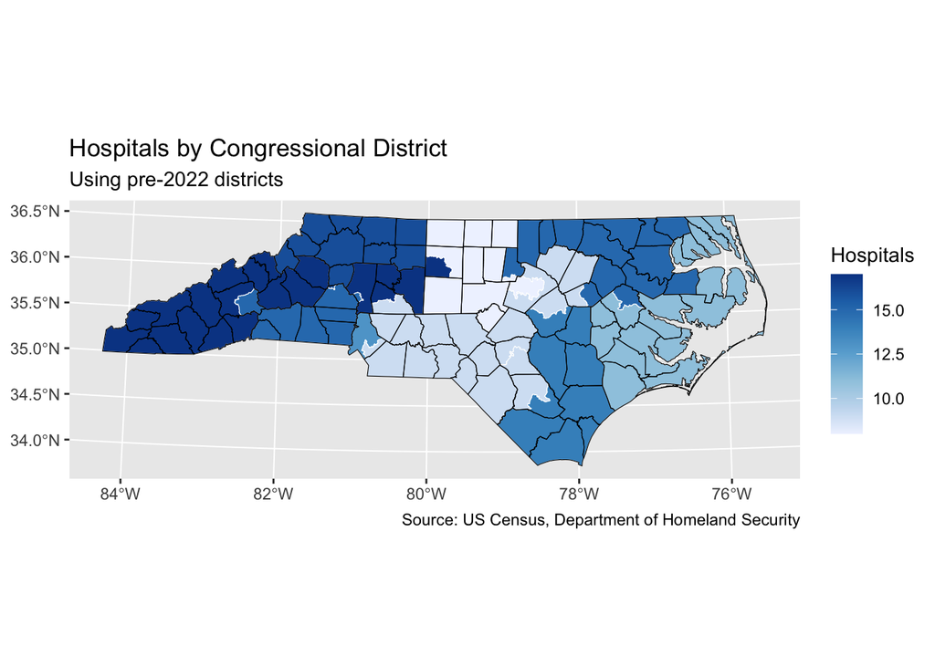

```r
ggplot() +
  geom_sf(data= by_cd, aes(fill = hospitals), color="white") +
  geom_sf(data=ncpop, fill=NA, color="black") +
  labs(title = "Hospitals by Congressional District",
       subtitle = "Using pre-2022 districts",
       caption = "Source: US Census, Department of Homeland Security",
       fill = "Hospitals") +
  scale_fill_distiller(direction=1)
```

## Part 3: Building interactive maps with Leaflet

These maps we’ve made so far are lovely … if the internet didn’t exist. I don’t know about you, but when I see a map I want to click around on it and get more information than can reasonably be presented in just two dimensions. This is where interactive maps come in. We’re going to use a javascript library called Leaflet to build interactive web maps.

(This section is largely based on Andrew Tran’s tutorials and uses data he compiled and published. His section on “Interactive maps with Leaflet” is a good reference, although some of the methods and functions found in these 2018 tutorials may no longer work: https://learn.r-journalism.com/en/mapping/leaflet_maps/leaflet/ )

Reference: https://rstudio.github.io/leaflet/

```r
#install.packages("leaflet")
library(leaflet)
```

Building a leaflet map is a little like using ggplot. First you initialize a canvas on which we can paint the map.

(Note that rendering leaflet maps inside an Rmd file can result in frustrating scroll-and-zoom hell. So until you’re ready to render the entire Rmd as an html document, I recommend building the map objects in code chunks here, and then type the name of the code chunk down in the console. Doing so will render you map in the “Viewer” tab in the RStudio pane that is (probably) to the left.)

```r
my_first_map <- leaflet()
```

Not to impressive, but we can tell something is happening.

Let’s add the picture of the map. The cool kids call these the “tiles” of the “basemap.”

To start, we’re going to use the default tiles, which come from the free-to-use OpenStreetMap project.

References: * https://rstudio.github.io/leaflet/basemaps.html * https://www.openstreetmap.org/about

```r
my_first_map <- leaflet() %>%
  addTiles()
```

To avoid that uncomfortable Thanksgiving table conversation, let’s zoom our map in on good ol’ Chapel Hill

```r
my_first_map <- leaflet() %>%
  addTiles() %>%
  setView(lng=-79.055847, lat=35.913200, zoom = 16)
```

And just in case you haven’t memorized the latitude and longitude of the Franklin/Columbia street intersection, you can use Google Maps to find it. Just pick a spot on the map and left or CTRL-click on that spot to see the coordinates.

Finally, we can add a marker for the center of the known basketball universe.

```r
my_first_map <- leaflet() %>%
  addTiles() %>%
  setView(lng=-79.055847, lat=35.913200, zoom = 16) %>%
  addMarkers(lng=-79.055847, lat=35.913200, popup="Center of the Basketball Universe")
```

Finally, let’s tell the internets about the center of the basketball universe. In the Viewer tab, click on “Export” and then select “Save as a Web Page”. This will give you all the HTML, CSS, and JavaScript you need to embed or further customize the map.

#14. Make a map that creates a marker for the Dean Dome.

- Bonus: Show your users this photo when they click on the marker: https://live.staticflickr.com/8081/8323313113_96f3b83d97_b.jpg
- Double Bonus: Play a video of Rick Astley’s “Never Going to Give You Up” when they click on your Dean Dome marker.

```r
# Initialize and assign m as the leaflet object
m <- leaflet() %>%
# Now add tiles to it
    addTiles() %>%
# Setting the middle of where the map should be and the zoom level
    setView(lng=-79.055847, lat=35.913200, zoom = 16) %>%
# Now, add a marker with a popup,
    addMarkers(lng=-79.04361611653671, lat=35.900724533305755, popup="<img src='https://live.staticflickr.com/8081/8323313113_96f3b83d97_b.jpg'>")

#<iframe width="560" height="315" src="https://www.youtube.com/embed/dQw4w9WgXcQ" title="YouTube video player" frameborder="0" allow="accelerometer; autoplay; clipboard-write; encrypted-media; gyroscope; picture-in-picture" allowfullscreen></iframe>

m
```

[interactive chart not shown]

Now it’s time to map a lot of points or polygons.

For this exercise, we’re going to make a map of (outdated) locations of all the Dunkin’s (or is it Dunkin’es) and Starbucks in North Carolina.

```r
setwd("~/Documents/Teaching/570-data/Data - 2022 Fall/assignments/exercises")
dunkin <- read_csv("11dunkin.csv")
```

Our files will get way unnecessarily big and our computer will slow to a crawl if we keep working with every Dunkin’ location instead of just focusing on North Carolina.

```r
dd_state <- dunkin %>%
  filter(state=="NC")

dd_state
```

```
## # A tibble: 303 × 9
##        id address                 city     state   zip country   lat   lon type
##     <dbl> <chr>                   <chr>    <chr> <dbl> <chr>   <dbl> <dbl> <chr>
##  1 306810 3209 S Wilmington St    Raleigh  NC    27603 US       35.7 -78.6 Dunk…
##  2 307178 5111 Market St          Wilming… NC    28405 US       34.2 -77.9 Dunk…
##  3 307442 2120 Stone Rose Dr      Rocky M… NC    27804 US       36.0 -77.8 Dunk…
##  4 307528 433a Western Blvd       Jackson… NC    28546 US       34.8 -77.4 Dunk…
##  5 308349 2515 S 17th St          Wilming… NC    28401 US       34.2 -77.9 Dunk…
##  6 330174 7815 N Point Blvd       Winston… NC    27106 US       36.2 -80.3 Dunk…
##  7 330299 113 E Main St           Havelock NC    28532 US       34.9 -76.9 Dunk…
##  8 330489 2908 Arendell St        Morehea… NC    28557 US       34.7 -76.7 Dunk…
##  9 331733 5611a Carolina Beach Rd Wilming… NC    28412 US       34.1 -77.9 Dunk…
## 10 331785 7137 Us Hwy 64 East     Knightd… NC    27545 US       35.8 -78.5 Dunk…
## # … with 293 more rows
```

```r
#Note that this is a tibble, not an sf object. R doesn't yet know that the lat and lon columns are geographic coordinates.
```

A lot of what we’re going to do next will look familiar. But we’re going to do two new things: * Try out a new style of map tiles(https://leaflet-extras.github.io/leaflet-providers/preview/index.html) * Use the addCircles() function from leaflet to map data from our dd_state dataframe.

In this example we use the “lon” column (which could be named anything) to tell leaflet that this is where it should find the longitude of each marker’s center point. We then tell it to use the “lat” column (which could be named anything) to tell leaflet that this is where it should find the latitude of each marker’s center point. We then tell leaflet to use the text of each row’s “type” column as the text in the popup box. Finally, we set constants for the weight, radius, color, stroke and fillOpacity of the circles we want to draw. But we could also use values in one our dataframe’s columns to create variable values for any of these circle attributes. For example, we could make the radius of every circle represent the number of MUNCHKINS sold at each location. (Why we need the tildes? Because I said so.)

```r
m2 <- leaflet(dd_state) %>%
  addProviderTiles(providers$CartoDB.DarkMatter) %>%
  setView(-79.055847, 35.913200, zoom = 7) %>%
  addCircles(lng=~lon,
             lat=~lat,
             popup=dunkin$type,
             weight = 3,
             radius=40,
             color="#ffa500",
             stroke = TRUE,
             fillOpacity = 0.8)

m2
```

[interactive chart not shown]

Remember to view your object in the viewer so you can see my least favorite portion of I-40 between here and Wrightsville Beach.

# 15. Use the 11starbucks.csv file to create a map of Starbucks locations in North Carolina. Pick a different style of tiles to use, display the store hours in the popup, and change the color of the cirlces to Starbucks green.

```r
setwd("~/Documents/Teaching/570-data/Data - 2022 Fall/assignments/exercises")
#HINT: library(janitor)

starbucks <- read_csv("11starbucks.csv")
sb_state <- starbucks %>%
  filter(Province=="NC")

sb_state <- janitor::clean_names(sb_state)

m15 <- leaflet(sb_state) %>%
  addProviderTiles(providers$Stamen.Toner) %>%
  setView(-79.055847, 35.913200, zoom = 7) %>%
  addCircles(lng=~lon,
             lat=~lat,
             popup=sb_state$store_hours,
             weight = 3,
             radius=40,
             color="#006439",
             stroke = TRUE,
             fillOpacity = 0.8)
m15
```

[interactive chart not shown]

### Time for another break

Andrew Tran’s tutorial shows us how we can bind these two dataframes together and use the “type” column to generate one color of cirlces for the Dunkin’ locations and another color for the Starbucks locations.

```r
# isolating just the 3 columns we're interested in-- type, lat, and lon
sb_loc <- select(sb_state, type, lat, lon)
dd_loc <- select(dd_state, type, lat, lon)

# joining the two data frames together
ddsb <- bind_rows(sb_loc, dd_loc)

# creating a coffee color palette

pal <- colorFactor(palette=c("#ffa500", "#13ED3F"),
                   levels=c("Dunkin Donuts", "Starbucks"))

#("levels" and "domain" are interchangeable arguments as of Novemeber 2022.)


# mapping based on type
m3 <- leaflet(ddsb) %>%
  addProviderTiles(providers$CartoDB.DarkMatter) %>%
  setView(-79.055847, 35.913200, zoom = 7) %>%
  addCircleMarkers(~lon, ~lat,
                   popup=ddsb$type,
                   weight = 3,
                   radius=4,
#here's the one new line that tells leaflet to set the color based on the value in the "type" column and to use the custom palette to match a specific color to each value.
                   color=~pal(type),
                   stroke = F,
                   fillOpacity = 0.5)
m3
```

[interactive chart not shown]

Finally, note that you can create a foundational map object and then test out little additions to it without re-typing all that code. Here we test out adding a legend.

```r
m4 <- m3 %>%
  addLegend("bottomright",
            colors= c("#ffa500", "#13ED3F"),
            labels=c("Dunkin'", "Starbucks"),
            title="Coffee places")

m4
```

[interactive chart not shown]

# 17. Which congressional districts have the most Starbucks?

I’m sure someone has done this at least 15 years ago, but I’ll bet there’s a correlation between the number of Starbucks in a congressional district and its partisan leanings.

This might sound like a good ol’ fashioned points-in-polygon analysis. But only one problem – our points aren’t in a sf object at all, nevermind being in the same projection as the polygon layer of congressional districts.

With a little careful work, we can use the `st_as_sf()` function from the sf package to convert a plain old dataframe into a geographic sf object.

```r
sb_state_sf <- sf::st_as_sf(sb_state,
#Which columns contain the lat and long? Be sure to put them in the 'wrong' order.
                            coords = c("lon","lat"),
#This line just establishes a crs
                            crs = "+proj=longlat") %>%
#Get our data in the same project as the data we want to join
  sf::st_transform(crs=sf::st_crs(cds))
```

Now that you’ve got two sf objects with matching crs, go ahead and do a spatial join and then organize the data so you have one row for each congressional district and a column called “total” that shows the number of Starbucks locations in the district. HINT: You’ll have three columns: NAME, locations, geometry.

```r
sbxcd <- sf::st_join(cds, sb_state_sf)

sbxcd<- sbxcd %>%
  group_by(NAME) %>%
  summarize(total=n())
```

```r
# Creating a color palette based on the number range in the total column
pal_sb <- colorNumeric("Greens", domain=sbxcd$total)
```

```r
# Setting up the pop up text
popup_sb <- paste0("There are ",as.character(sbxcd$total), " Starbucks in ",sbxcd$NAME )
```

```r
# Getting rid of rows with NA values
# Using the Base R method of filtering subset() because we're dealing with a SpatialPolygonsDataFrame and not a normal data frame, thus filter() wouldn't work

#sbxcd <- subset(sbxcd, !is.na(total))
```

```r
sbxcd <- sf::st_transform(sbxcd, crs = 4326)


m17 <- leaflet() %>%
  addProviderTiles("CartoDB.Positron") %>%
  setView(-79.055847, 35.913200, zoom = 7) %>%
  addPolygons(data = sbxcd ,
              fillColor = ~pal_sb(sbxcd$total),
              fillOpacity = 0.7,
              weight = 0.2,
              smoothFactor = 0.2,
              popup = ~popup_sb) %>%
  addLegend(pal = pal_sb,
            values = sbxcd$total,
            position = "bottomright",
            title = "Starbucks")

m17
```

[interactive chart not shown]